# Week 6: Analysis of longitudinal data

## Reading the datasets, factoring and structures

```r
library(ggplot2); library(dplyr); library(tidyr)

RATSL <- read.csv(file = "data/RATSL.csv")
RATSL$ID <- factor(RATSL$ID)
RATSL$Group <- factor(RATSL$Group)
str(RATSL)
```

```
## 'data.frame':    176 obs. of  5 variables:
##  $ ID    : Factor w/ 16 levels "1","2","3","4",..: 1 2 3 4 5 6 7 8 9 10 ...
##  $ Group : Factor w/ 3 levels "1","2","3": 1 1 1 1 1 1 1 1 2 2 ...
##  $ WD    : Factor w/ 11 levels "WD1","WD15","WD22",..: 1 1 1 1 1 1 1 1 1 1 ...
##  $ weight: int  240 225 245 260 255 260 275 245 410 405 ...
##  $ Time  : int  1 1 1 1 1 1 1 1 1 1 ...
```

```r
BPRSL <- read.csv(file = "data/BPRSL.csv")
BPRSL$treatment <- factor(BPRSL$treatment)
BPRSL$subject <- factor(BPRSL$subject)
str(BPRSL)
```

```
## 'data.frame':    360 obs. of  5 variables:
##  $ treatment: Factor w/ 2 levels "1","2": 1 1 1 1 1 1 1 1 1 1 ...
##  $ subject  : Factor w/ 20 levels "1","2","3","4",..: 1 2 3 4 5 6 7 8 9 10 ...
##  $ weeks    : Factor w/ 9 levels "week0","week1",..: 1 1 1 1 1 1 1 1 1 1 ...
##  $ bprs     : int  42 58 54 55 72 48 71 30 41 57 ...
##  $ week     : int  0 0 0 0 0 0 0 0 0 0 ...
```

In RATS data we have three groups, who were put on different diets. Then each rat was weighted repeatedly over a nine week period. The question of most interest is whether the growth profiles of the three groups differ.

In BPRS data we had two different treatment groups, whose BPRS (the psychiatric rating scale) was measured on 9 weeks. The question of interest is whether two different treatments differed.

## 1) Analyses on RATS data

### Graphs

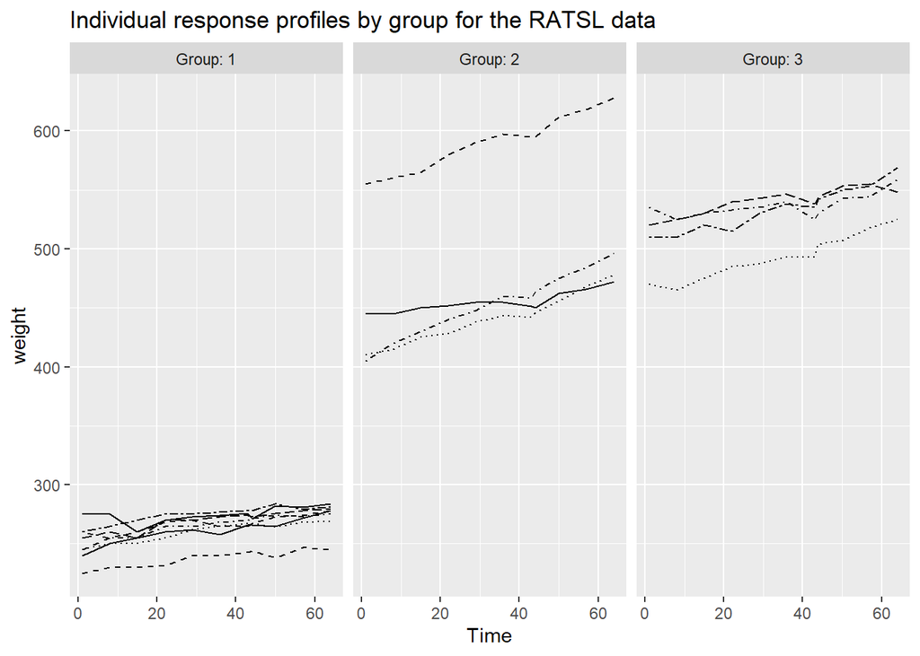

```r
# Graphical display of RATS

ggplot(RATSL, aes(x = Time, y = weight, linetype = ID)) +
  geom_line() +
  scale_linetype_manual(values = rep(1:10, times=4)) +
  facet_grid(. ~ Group, labeller = label_both) +
  theme(legend.position = "none") +
  scale_y_continuous(limits = c(min(RATSL$weight), max(RATSL$weight))) +
  ggtitle("Individual response profiles by group for the RATSL data")
```

We see that in all groups the weigth seems to increase when time increases. In groups 2 and 3 increase is more clear. Graph shows us that there seems to be a difference in baseline weights at least between Group 1 vs other Groups. Groups 2 ja 3 are more similar. In every group there is one unsual individual, who we migth delete later.

### Standardized graphs

```r
RATSL <- RATSL %>%
  group_by(Time) %>%
  mutate(stweigth = (weight - mean(weight))/sd(weight) ) %>%
  ungroup()

glimpse(RATSL)
```

```
## Observations: 176
## Variables: 6
## $ ID       <fct> 1, 2, 3, 4, 5, 6, 7, 8, 9, 10, 11, 12, 13, 14, 15, 16...
## $ Group    <fct> 1, 1, 1, 1, 1, 1, 1, 1, 2, 2, 2, 2, 3, 3, 3, 3, 1, 1,...
## $ WD       <fct> WD1, WD1, WD1, WD1, WD1, WD1, WD1, WD1, WD1, WD1, WD1...
## $ weight   <int> 240, 225, 245, 260, 255, 260, 275, 245, 410, 405, 445...
## $ Time     <int> 1, 1, 1, 1, 1, 1, 1, 1, 1, 1, 1, 1, 1, 1, 1, 1, 8, 8,...
## $ stweigth <dbl> -1.0011429, -1.1203857, -0.9613953, -0.8421525, -0.88...
```

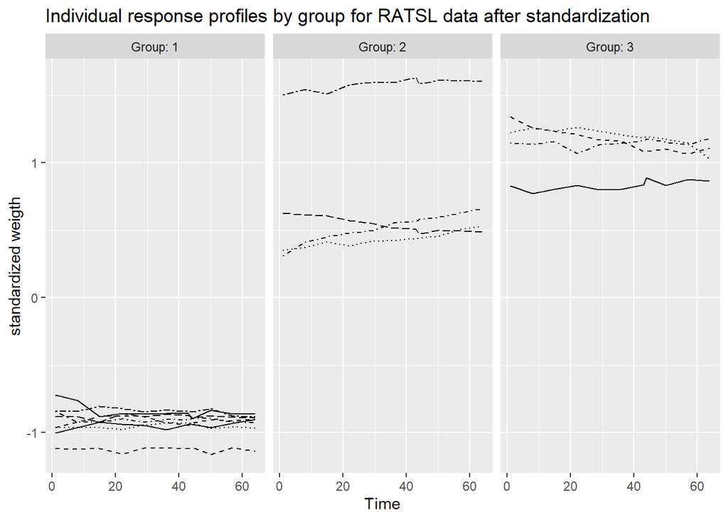

```r
ggplot(RATSL, aes(x = Time, y = stweigth, linetype = ID)) +
  geom_line() +
  scale_linetype_manual(values = rep(1:16, times=4)) +
  facet_grid(. ~ Group, labeller = label_both) +
  theme(legend.position = "none") +
  scale_y_continuous(name = "standardized weigth") +
  ggtitle("Individual response profiles by group for RATSL data after standardization")
```

With standardized values we see more clearly, that there is one outlier observartion in each group.

In Group 1 the weigth profile seem to be pretty much the same over time points. In Group 3 there is a small decrease in weigths over time. Only in Group 2 the weigth profiles seem to increase.

### Summary graph

```r
# Number of time, baseline (week 0) included
n <- RATSL$Time %>% unique() %>% length()

# Summary data with mean and standard error of bprs by treatment and week
RATSS <- RATSL %>%
  group_by(Group, Time) %>%
  summarise(mean = mean(weight), se = sd(weight)/sqrt(n) ) %>%
  ungroup()

# Glimpse the data
glimpse(RATSS)
```

```
## Observations: 33
## Variables: 4
## $ Group <fct> 1, 1, 1, 1, 1, 1, 1, 1, 1, 1, 1, 2, 2, 2, 2, 2, 2, 2, 2,...
## $ Time  <int> 1, 8, 15, 22, 29, 36, 43, 44, 50, 57, 64, 1, 8, 15, 22, ...
## $ mean  <dbl> 250.625, 255.000, 254.375, 261.875, 264.625, 265.000, 26...
## $ se    <dbl> 4.589478, 3.947710, 3.460116, 4.100800, 3.333956, 3.5529...
```

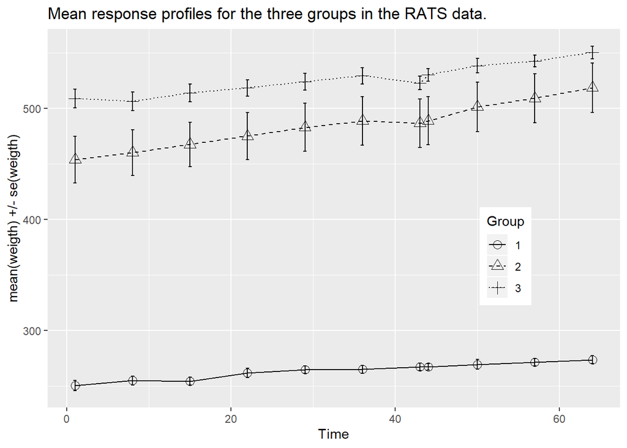

```r
# Plot the mean profiles
ggplot(RATSS, aes(x = Time, y = mean, linetype = Group, shape = Group)) +
  geom_line() +
  scale_linetype_manual(values = c(1,2,3)) +
  geom_point(size=3) +
  scale_shape_manual(values = c(1,2,3)) +
  geom_errorbar(aes(ymin=mean-se, ymax=mean+se, linetype="1"), width=0.4) +
  theme(legend.position = c(0.8,0.4)) +
  scale_y_continuous(name = "mean(weigth) +/- se(weigth)") +
  ggtitle("Mean response profiles for the three groups in the RATS data.")
```

The mean profiles plot shows that the error bars do not overlap.

### Mean as a summary measure

```r
# Create a summary data by treatment and subject with mean as the summary variable (ignoring baseline week 0).
RATSL10S <- RATSL %>%
  filter(Time > 0) %>%
  group_by(Group, ID) %>%
  summarise( mean=mean(weight) ) %>%
  ungroup()

# Glimpse the data
glimpse(RATSL10S)
```

```
## Observations: 16
## Variables: 3
## $ Group <fct> 1, 1, 1, 1, 1, 1, 1, 1, 2, 2, 2, 2, 3, 3, 3, 3
## $ ID    <fct> 1, 2, 3, 4, 5, 6, 7, 8, 9, 10, 11, 12, 13, 14, 15, 16
## $ mean  <dbl> 261.0909, 237.6364, 260.1818, 266.5455, 269.4545, 274.72...
```

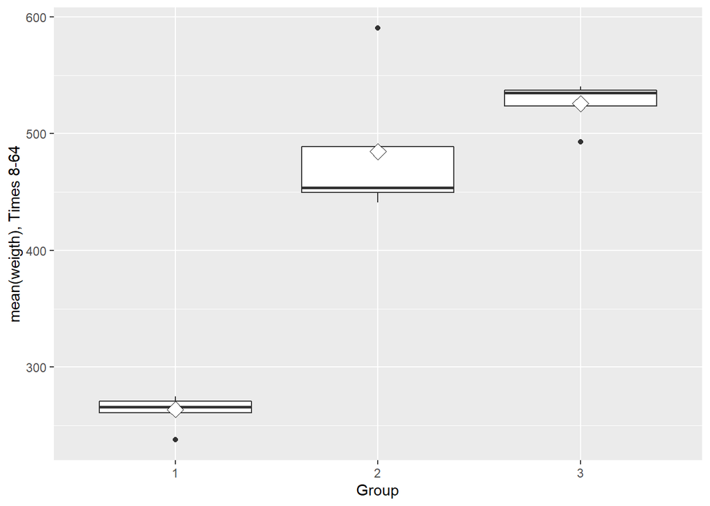

```r
# Draw a boxplot of the weigth mean versus group
ggplot(RATSL10S, aes(x = Group, y = mean)) +
  geom_boxplot() +
  stat_summary(fun.y = "mean", geom = "point", shape=23, size=4, fill = "white") +
  scale_y_continuous(name = "mean(weigth), Times 8-64")
```

Here is a plot of mean as a summary variable.  
We can see three outlier observations, one in each group. Let’s remove these and draw the plot again.

```r
# Create a new data by filtering the outlier and adjust the ggplot code the draw the plot again with the new data
RATSL10S1 <- RATSL10S %>%
  filter((mean < 550 & mean > 500 )|  (mean > 250 & mean < 475))


glimpse(RATSL10S1)
```

```
## Observations: 13
## Variables: 3
## $ Group <fct> 1, 1, 1, 1, 1, 1, 1, 2, 2, 2, 3, 3, 3
## $ ID    <fct> 1, 3, 4, 5, 6, 7, 8, 9, 10, 11, 14, 15, 16
## $ mean  <dbl> 261.0909, 260.1818, 266.5455, 269.4545, 274.7273, 274.63...
```

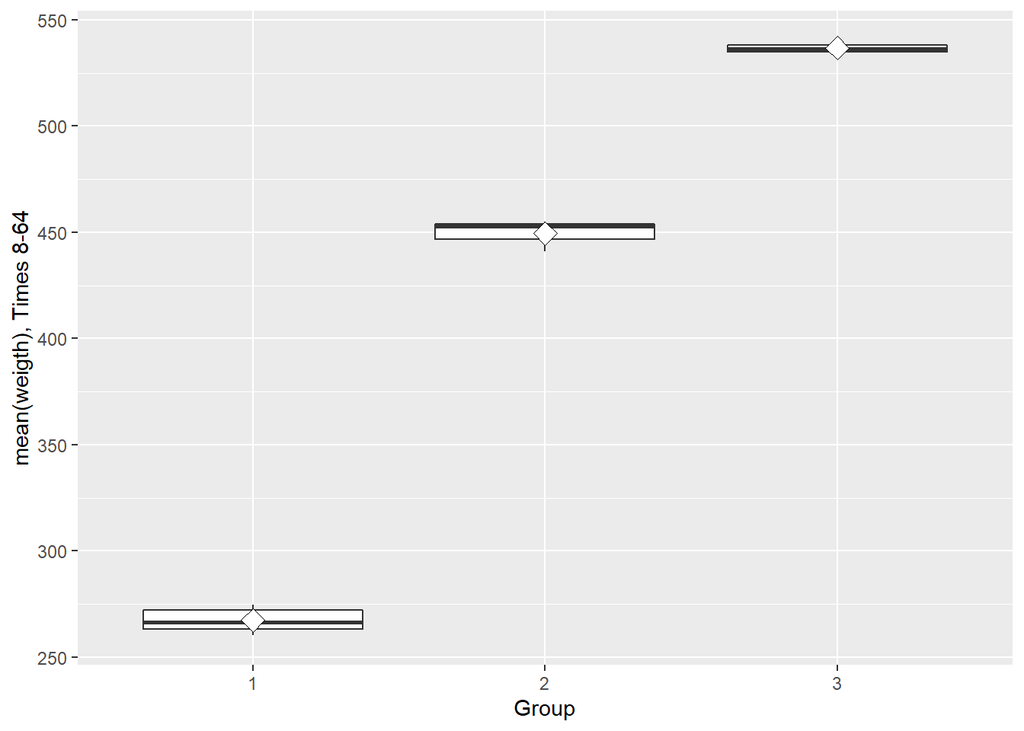

```r
ggplot(RATSL10S1, aes(x = Group, y = mean)) +
  geom_boxplot() +
  stat_summary(fun.y = "mean", geom = "point", shape=23, size=4, fill = "white") +
  scale_y_continuous(name = "mean(weigth), Times 8-64")
```

Now without those three observations, the group summaries look very good.